# Tutorial 4

1. Activity: Inference from Causal Explanations
2. Type Causation and Token Causation
3. Counterfactuals
4. Token Causation Revisited
5. Causal Selection
   - Abnormal inflation
   - Normal inflation

## Activity: Blicket experiment with explanations!

In this activity you will pretend to be experimenters and participants, looking to see how well people generalize causal relationships from experiments *and* explanations.

### Procedure

*Experimenter:*

Grab several (6-10) objects and place them in a bag. Select 2-3 objects to be blickets.

Two conditions:

| Known rule | Known blickets |
| --- | --- |
| You tell the participant what the rule for the blicket detector is | You tell the participant which objects are blickets |

Keep in mind that if your detector requires 2 or 3 blickets then you should have at least that many blickets in your three objects (to be nice). Then, you must pick a blicket machine:

- Disjunctive (any blicket will make the machine go off)
- Conjunctive (requires two blickets for the machine to go off)
- Anything more complex
  - exactly 1 or 2 blickets
  - Blicket and a non Blicket (mean one)
  - etc.

When your participant places 2-3 onjects on the blicket machine you must tell them:

- If the machine turns on
- Why the machine turned on
  - Point to any of the objects on the machine

*Participant*

Your job as is to determine what objects are blickets or what makes the detector go off (depending on condition).

**You have 3 experiments you can conduct** selecting any set of the objects and place them on the machine. The experimenter will tell you if the detector turns on.

I recommend you write down your results.

## Type and Token Causes

### **Type causation**

Type causation refers to the variables in a causal model:

$ A \rightarrow C \leftarrow B$

The type causation relations are:

- $A$ causes $C$
  - when $A>18$: (meets condition)
- $B$ causes $C$
  - when $B=True$: (happens)

### **Token events**

Each causal variable is presumed to have a domain of posible values:

- $A \in \mathbb{Z}$ (Integers)
- $B \in \{True,False\}$
- $C \in \{True,False\}$

Token events represent the values that the causal variables can take on:

- $A=20$
- $B=True$
- $C=True$

### **Token causation**

Other names for this phenomenon are:

- Actual Causation
- Token Caustion
- Singular Causation

Given the type level causal relations do we know when token events actually cause other events?

- Did ($A=20$) cause ($C=True$)?
- Did ($B=True$) cause ($C=True$)?

# Counterfactuals

Counterfactuals presuppose there having been a token event---something has to *actually* happen.

Counterfactuals state judgments about what would have happened *counter* to the (f)actual world.

[output not shown]

1. *What are the type level causes of this scenario?*
2. *What are the token events this scenario?*

Lewis (1973) provides a semantics for counterfactuals.

Given {$A=a$ , $B=b$}

If $A$ had not ($A=a$), then $B$ would not have ($B=b$).

This is true only if in all the *closest* worlds to the actual world in which $A$ takes on values ($A\neq a$), $B$ takes on values ($B\neq b$).

## Token Causation Revisited

So if the vase is shattered, what is the *token*/*actual* cause of it shattering?

Popular theory: **Counterfactual Dependence**

Billy throwing the vase is a token cause because *if Billy had not thrown the ball, the vase would not have shattered*. Thus, the vase shattering counterfactually depends on Billy throwing the ball.

What about the following cases:

- If the vase had been covered by a plastic case, the vase would not have shattered.
  - Presupposition: The vase was not covered by a plastic case.
- If Suzy had stopped Billy from throwing the ball, the vase would not have shattered.
  - Presupposition: Suzy did not stop Billy from throwing the ball.

All of these satisfy the counterfactual dependence condition...

### Which one is **the** *token/actual* cause?

# Causal Selection

Alice and Bob are playing a special game of basketball. In this game they are on a team and they need to score a basket to win.

In one case 1. both of them needs to score to win, in the other 2. only one of them need to score a basket to win.

$ A \rightarrow W \leftarrow B$

1. $W := A=1 \land B=1$
2. $W := A=1 \lor B=1$

Suppose we know Alice is a spectacular basketball shooter, and Bob is new and not quite good at scoring baskets.

One way to represent this probabilistically is to say: $P(A=1) > P(B=1)$

Suppose we are in a situation where both Alice and Bob scored a basket, and they won the game!

### *Who is the cause of the team winning?*

### Abnormal Inflation:

When multiple events are necessary, the occurence of the **abormal** event is more likely to be consdered the cause.

### Normal Inflation:

When multiple events are sufficient, the occurence of the **normal** event is more likely to be consdered the cause.

### Examples from (Kirfel et al, 2021)

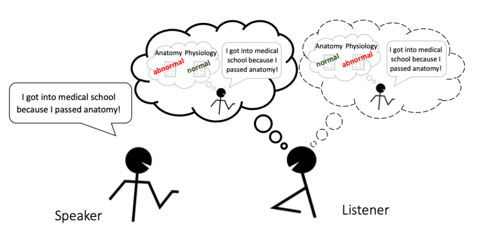

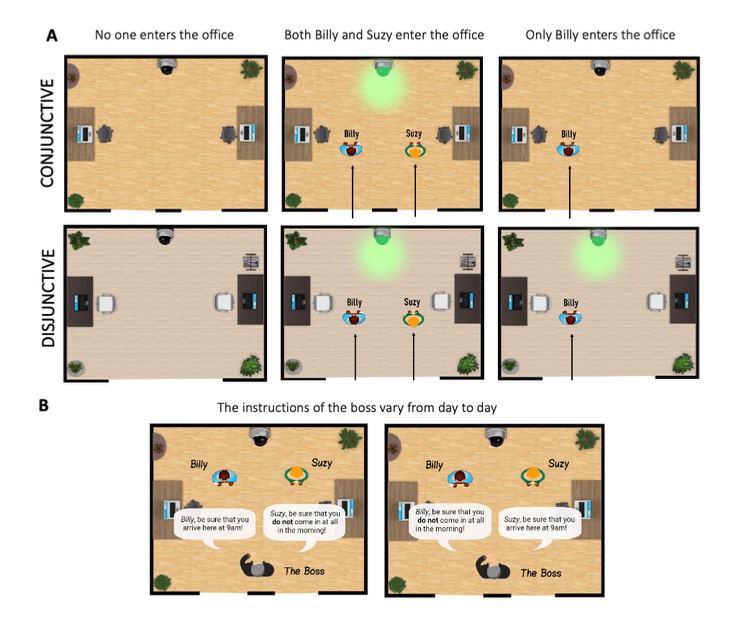

## Theories of Causal Selection

These are theories that aim to find the token causes and their rspective effect size.

Related idea is causal *blame* (Zultan et al, 2012) and *responsibility* (Lagnado et al, 2013).

### Necesity and Sufficiency (Icard et al., 2017)

How necessary is the event to cause the outcome?

- Maximum score if necessary in all conditions
- Somewhat necessary if necessary *under different conditions*

How sufficient is the event to cause the outcome?

- Maximum score if sufficient alone
- Somewhat sufficient if sufficient *under different conditions*

How these *different conditions* are defined is what gives variability and explanatory power to this theory.

### Counterfactual Effect Size (Quillien & Lucas, 2023)

Considers which variable has the strongest effect size across counterfactual worlds.

Like Lewis, this considers the most normal and closest worlds to the actual world.

[figure not shown]

Then in each world it counts wether changing the cause would have an effect on the outcome.

$ \kappa_{C \rightarrow E} = \frac{1}{n} \frac{\sigma_C}{\sigma_E} \sum_i (\frac{\Delta E}{ \Delta C} )_i $